# Cell and Column Types

```r
library(readxl)
```

`readxl::read_excel()` will guess column types, by default, or you can provide them explicitly via the `col_types` argument. The `col_types` argument is more flexible than you might think; you can mix actual types in with `"skip"` and `"guess"` and a single type will be recycled to the necessary length.

Here are different ways this might look:

```r
read_excel("yo.xlsx")
read_excel("yo.xlsx", col_types = "numeric")
read_excel("yo.xlsx", col_types = c("date", "skip", "guess", "numeric"))
```

## Type guessing

If you use other packages in the [tidyverse](http://tidyverse.org), you are probably familiar with [readr](http://readr.tidyverse.org), which reads data from flat files. Like readxl, readr also provides column type guessing, but readr and readxl are very different under the hood.

- readr guesses column type *based on the data*.
- readxl guesses column type *based on Excel cell types*.

Each cell in an Excel spreadsheet has its own type. For all intents and purposes, they are:

empty < boolean < numeric < text

with the wrinkle that datetimes are a very special flavor of numeric. A cell of any particular type can always be represented as one of any higher type and, possibly, as one of lower type. When guessing, `read_excel()` keeps a running “maximum” on the cell types it has seen in any given column. Once it has visited `guess_max` rows or run out of data, this is the guessed type for that column. There is a strong current towards “text”, the column type of last resort.

Here’s an example of column guessing with `deaths.xlsx` which ships with readxl.

```r
read_excel(readxl_example("deaths.xlsx"), range = cell_rows(5:15))
```

```
#> # A tibble: 10 × 6
#>            Name Profession   Age `Has kids` `Date of birth`
#>           <chr>      <chr> <dbl>      <lgl>          <dttm>
#> 1   David Bowie   musician    69       TRUE      1947-01-08
#> 2 Carrie Fisher      actor    60       TRUE      1956-10-21
#> 3   Chuck Berry   musician    90       TRUE      1926-10-18
#> 4   Bill Paxton      actor    61       TRUE      1955-05-17
#> # ... with 6 more rows, and 1 more variables: `Date of death` <dttm>
```

## Excel types, R types, `col_types`

Here’s how the Excel cell/column types are translated into R types and how to force the type explicitly in `col_types`:

| How it is in Excel | How it will be in R | How to request in `col_types` |
| --- | --- | --- |
| *anything* | *non-existent* | `"skip"` |
| empty | `logical`, but all `NA` | *you cannot request this* |
| boolean | `logical` | `"logical"` |
| numeric | `numeric` | `"numeric"` |
| datetime | `POSIXct` | `"date"` |
| text | `character` | `"text"` |
| *anything* | `list` | `"list"` |

Some explanation about the weird cases in the first two rows:

- If a column falls in your data rectangle, but you do not want an associated variable in the output, specify the column type `"skip"`. Internally, these cells may be visited in order to learn their location, but they are not loaded and their data is never read.
- You cannot request that a column be included but filled with `NA`s. Such a column can arise naturally, if all the cells are empty, or you can skip a column (see previous point).

Example of skipping and guessing:

```r
read_excel(
  readxl_example("deaths.xlsx"),
  range = cell_rows(5:15),
  col_types = c("guess", "skip", "guess", "skip", "skip", "skip")
)
```

```
#> # A tibble: 10 × 2
#>            Name   Age
#>           <chr> <dbl>
#> 1   David Bowie    69
#> 2 Carrie Fisher    60
#> 3   Chuck Berry    90
#> 4   Bill Paxton    61
#> # ... with 6 more rows
```

More about the `"list"` column type in the last row:

- This will create a list-column in the output, each component of which is a length one atomic vector. The type of these vectors is determined using the logic described above. This can be useful if data of truly disparate type is arranged in a column.

```r
(clippy <-
   read_excel(readxl_example("clippy.xlsx"), col_types = c("text", "list")))
```

```
#> # A tibble: 4 × 2
#>                   name      value
#>                  <chr>     <list>
#> 1                 Name  <chr [1]>
#> 2              Species  <chr [1]>
#> 3 Approx date of death <dttm [1]>
#> 4      Weight in grams  <dbl [1]>
```

```r
tibble::deframe(clippy)
```

```
#> $Name
#> [1] "Clippy"
#>
#> $Species
#> [1] "paperclip"
#>
#> $`Approx date of death`
#> [1] "2007-01-01 UTC"
#>
#> $`Weight in grams`
#> [1] 0.9
```

```r
sapply(clippy$value, class)
```

```
#> [[1]]
#> [1] "character"
#>
#> [[2]]
#> [1] "character"
#>
#> [[3]]
#> [1] "POSIXct" "POSIXt"
#>
#> [[4]]
#> [1] "numeric"
```

Final note: all datetimes are imported as having the UTC timezone, because, mercifully, Excel has no notion of timezones.

## When column guessing goes wrong

It’s pretty common to expect a column to import as, say, numeric or datetime. And to then be sad when it imports as character instead. Two main causes:

**Contamination by embedded missing or bad data of incompatible type.** Example: missing data entered as `??` in a numeric column.

- Fix: use the `na` argument of `read_excel()` to describe all possible forms for missing data. This should prevent such cells from influencing type guessing and cause them to import as `NA` of the appropriate type.

**Contamination of the data rectangle by leading or trailing non-data rows.** Example: the sheet contains a few lines of explanatory prose before the data table begins.

- Fix: specify the target rectangle. Use `skip` and `n_max` to provide a minimum number of rows to skip and a maximum number of data rows to read, respectively. Or use the more powerful `range` argument to describe the cell rectangle in various ways. See the examples for `read_excel()` help or `vignette("sheet-geometry")` for more detail.

The `deaths.xlsx` sheet demonstrates this perfectly. Here’s how it imports if we don’t specify `range` as we did above:

```r
deaths <- read_excel(readxl_example("deaths.xlsx"))
print(deaths, n = Inf)
```

```
#> # A tibble: 18 × 6
#>                `Lots of people`                     X__1   X__2     X__3
#>                           <chr>                    <chr>  <chr>    <chr>
#> 1  simply cannot resist writing                     <NA>   <NA>     <NA>
#> 2                            at                      the    top     <NA>
#> 3                            or                  merging   <NA>     <NA>
#> 4                          Name               Profession    Age Has kids
#> 5                   David Bowie                 musician     69     TRUE
#> 6                 Carrie Fisher                    actor     60     TRUE
#> 7                   Chuck Berry                 musician     90     TRUE
#> 8                   Bill Paxton                    actor     61     TRUE
#> 9                        Prince                 musician     57     TRUE
#> 10                 Alan Rickman                    actor     69    FALSE
#> 11           Florence Henderson                    actor     82     TRUE
#> 12                   Harper Lee                   author     89    FALSE
#> 13                Zsa Zsa Gábor                    actor     99     TRUE
#> 14               George Michael                 musician     53    FALSE
#> 15                         Some                     <NA>   <NA>     <NA>
#> 16                         <NA> also like to write stuff   <NA>     <NA>
#> 17                         <NA>                     <NA> at the  bottom,
#> 18                         <NA>                     <NA>   <NA>     <NA>
#> # ... with 2 more variables: X__4 <chr>, X__5 <chr>
```

Non-data rows above and below the main data rectangle are causing all the columns to import as character.

If your column typing problem can’t be solved by specifying `na` or the data rectangle, request the `"list"` column type and handle missing data and coercion after import.

## Square pegs in round holes

You can force a column to have a specific type via `col_types`. So what happens to cells of another type? They will either be coerced to the requested type or to an `NA` of appropriate type.

For each column type, below we present a screen shot of a sheet from the built-in example `type-me.xlsx`. We force the first column to have a specific type and the second column explains what is in the first. You’ll see how mismatches between cell type and column type are resolved.

### Logical column

A numeric cell is coerced to `FALSE` if it is zero and `TRUE` otherwise. A date cell becomes `NA`. Just like in R, the strings “T”, “TRUE”, “True”, and “true” are regarded as `TRUE` and “F”, “FALSE”, “False”, “false” as `FALSE`. Other strings import as `NA`.

```r
df <- read_excel(readxl_example("type-me.xlsx"), sheet = "logical_coercion",
                 col_types = c("logical", "text"))
print(df, n = Inf)
```

```
#> # A tibble: 10 × 2
#>    `maybe boolean?`                      description
#>               <lgl>                            <chr>
#> 1                NA                            empty
#> 2             FALSE                      0 (numeric)
#> 3              TRUE                      1 (numeric)
#> 4                NA                         datetime
#> 5              TRUE                     boolean true
#> 6             FALSE                    boolean false
#> 7                NA                        "cabbage"
#> 8              TRUE                the string "true"
#> 9             FALSE                   the letter "F"
#> 10            FALSE "False" preceded by single quote
```

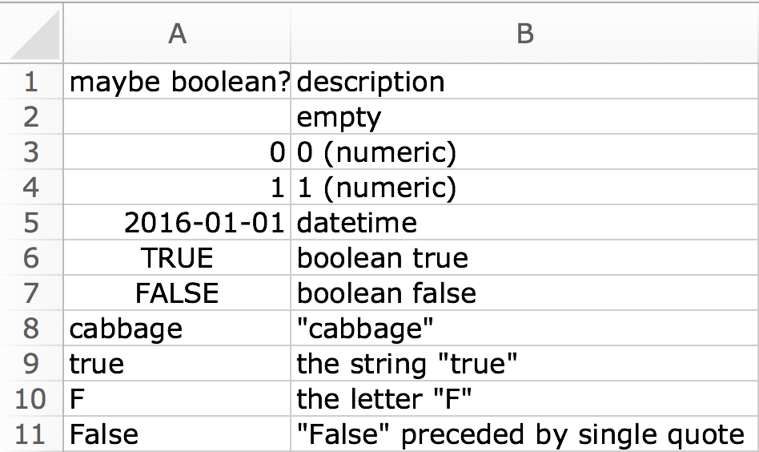

### Numeric column

A boolean cell is coerced to zero if `FALSE` and one if `TRUE`. A datetime comes in as the underlying serial date, which is the number of days, possibly fractional, since the [date origin](https://support.microsoft.com/en-us/help/214330/differences-between-the-1900-and-the-1904-date-system-in-excel). For text, numeric conversion is attempted, to handle the “number as text” phenomenon. If unsuccessful, text cells import as `NA`.

```r
df <- read_excel(readxl_example("type-me.xlsx"), sheet = "numeric_coercion",
                 col_types = c("numeric", "text"))
print(df, n = Inf)
```

```
#> # A tibble: 7 × 2
#>   `maybe numeric?`         explanation
#>              <dbl>               <chr>
#> 1               NA               empty
#> 2                1        boolean true
#> 3                0       boolean false
#> 4            40534            datetime
#> 5           123456 the string "123456"
#> 6           123456   the number 123456
#> 7               NA           "cabbage"
```

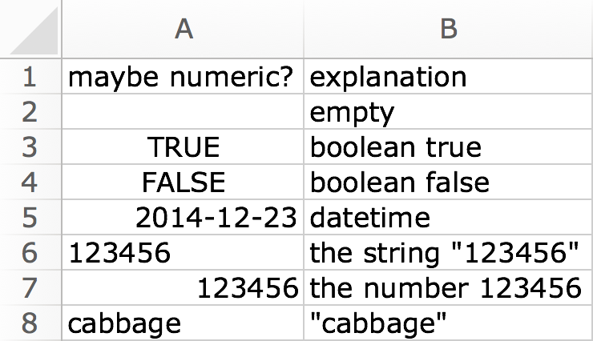

### Date column

A numeric cell is interpreted as a serial date (*I’m questioning whether this is wise, but https://github.com/tidyverse/readxl/issues/266*). Boolean or text cells become `NA`.

```r
df <- read_excel(readxl_example("type-me.xlsx"), sheet = "date_coercion",
                 col_types = c("date", "text"))
print(df, n = Inf)
```

```
#> # A tibble: 7 × 2
#>   `maybe a datetime?`          explanation
#>                <dttm>                <chr>
#> 1                <NA>                empty
#> 2 2016-05-23 00:00:00     date only format
#> 3 2016-04-28 11:30:00 date and time format
#> 4                <NA>         boolean true
#> 5                <NA>            "cabbage"
#> 6 1904-01-05 07:12:00        4.3 (numeric)
#> 7 2012-01-02 00:00:00      another numeric
```

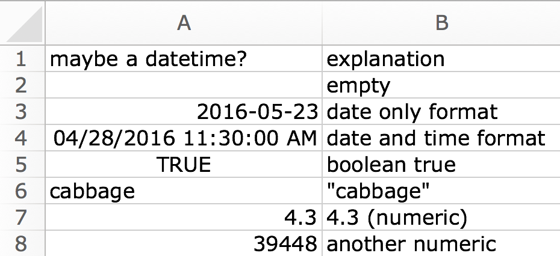

### Text or character column

A boolean cell becomes either `"TRUE"` or `"FALSE"`. A numeric cell is converted to character, much like `as.character()` in R. A date cell is handled like numeric, using the underlying serial value.

```r
df <- read_excel(readxl_example("type-me.xlsx"), sheet = "text_coercion",
                 col_types = c("text", "text"))
print(df, n = Inf)
```

```
#> # A tibble: 6 × 2
#>       text     explanation
#>      <chr>           <chr>
#> 1     <NA>           empty
#> 2  cabbage       "cabbage"
#> 3     TRUE    boolean true
#> 4      1.3         numeric
#> 5    41175        datetime
#> 6 36436153 another numeric
```

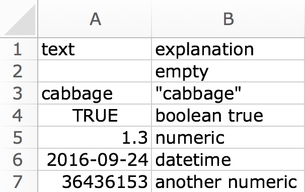